# Species-Level Diversity: More Than Population-Level Processes?

Macroevolution · PB 495/595 Plant Evolutionary Biology

George P. Tiley

29 October 2026

# Diversification

## Recap

- Popgen: allele frequencies within and among populations.
- Speciation: populations become separate lineages.
- Macroevolution: Explaining species richness through space and time.

## Learning objectives

By the end you should be able to:

- Distinguish microevolution from macroevolution.
- Describe how unevenly species are spread across the plant tree.
- Explain why richness depends on both clade age and net diversification rate, and estimate a rate with $\hat r = \ln n / t$.
- Describe the Yule and birth–death processes, and read a lineage-through-time plot.

# Scaling up

## Where “macroevolution” comes from

- Philiptschenko (1927) coined *micro-* and *macroevolution*. His student Dobzhansky brought the terms into English (Dobzhansky 1937).
- The Modern Synthesis view: macroevolution is microevolution added up over a long time (Simpson 1944).
- Examples that contradict the synthesis are plentiful (e.g. polyploidy speciation). Large-scale chromosomal changes long recognized as hopeful monsters (Goldschmidt 1940).
- A modern perspective incorporates gradualism, stochasticity, selection (shifts from expectations), and **constraints** (Gould 1980).

**Macroevolution** is a catch-all term for evolution at the species level and above.

## From populations to clades

|  | Microevolution | Macroevolution |
| --- | --- | --- |
| Units | alleles, individuals, populations | species (lineages), clades |
| Events | mutation, drift, selection, gene flow | speciation, extinction, trait change along lineages |
| Timescale | generations | $10^5$–$10^8$ years |
| Data | genotypes, allele frequencies, SFS | dated trees, trait data, metadata |
| Rates | per generation | per Myr |

## Species are born and die

- Species are separately evolving lineages (de Queiroz 2007).
- A lineage has a beginning (speciation), an end (extinction), and traits that its daughter species inherit.
- If some species leave more daughters, or last longer, this reflects the concepts of how differential survival and reproduction changes a population (Vrba and Gould 1986; Jablonski 2008).

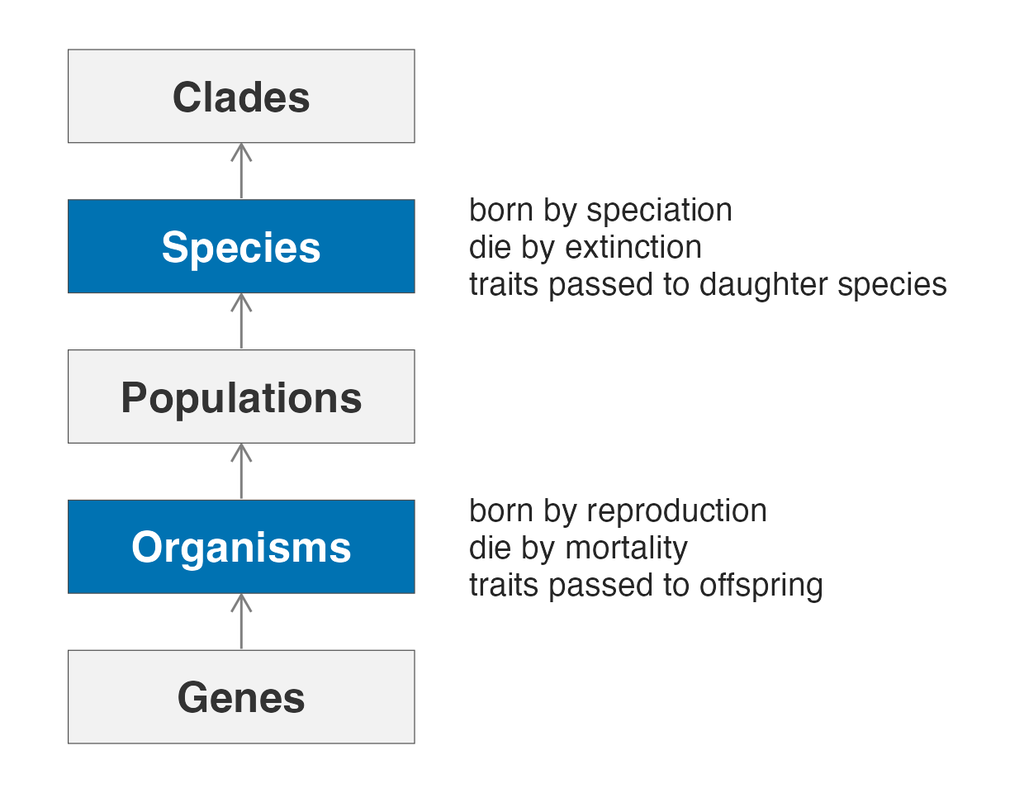

# The pattern: diversity is uneven

## How many plant species?

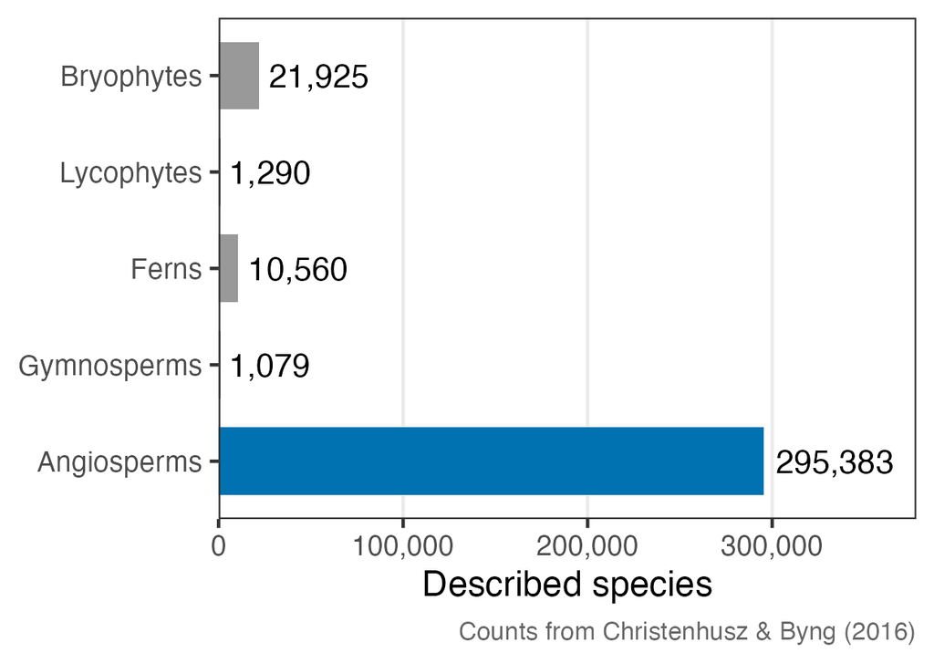

- Angiosperms are about 90% of land-plant species.
- They are *relatively* young. The crown of angiosperms is much younger than gymnosperms (Magallón et al. 2015).
- Is this surprising?

## Species per angiosperm order

Five of the 65 orders hold almost half of all angiosperm species.

[figure not shown]

## Species per family

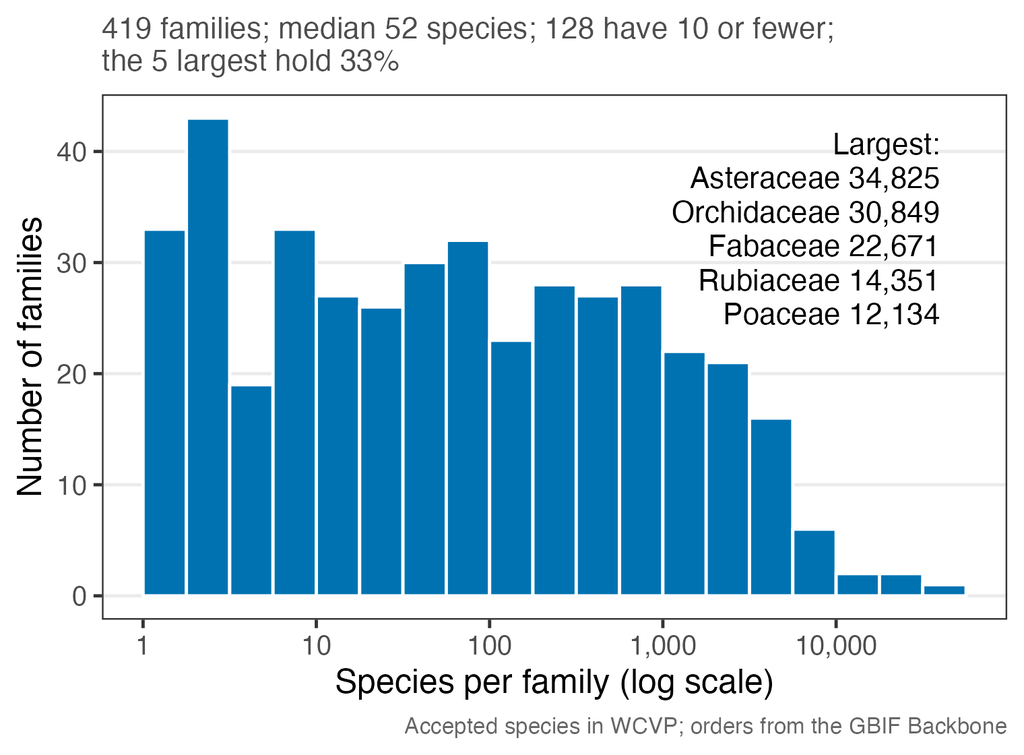

- The five largest families hold a third of all angiosperm species: Asteraceae, Orchidaceae, Fabaceae, Rubiaceae and Poaceae.
- The median family has 52 species, and 128 families have 10 or fewer.
- Early-diverging lineages are often small, like *Amborella* (1) and *Acorus* (5).

## Species per genus

- Most genera are tiny, but a few are very large (Willis and Yule 1922).
- About 28% of Angiosperm genera have a single species, but the bulk of diversity comes from some of the larger families we have discussed (Frodin 2004).
- What could explain this? Time, rates of speciation that differ among lineages, key innovations, ecological opportunity.

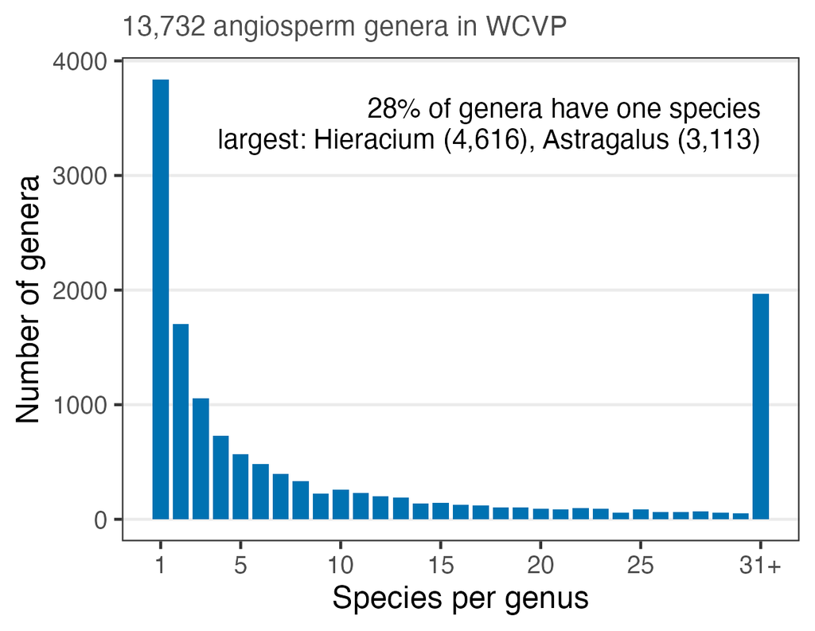

## Variation in species numbers

Can we develop a conceptual framework for how species numbers vary among lineages?

# Time or rate?

## The Yule process

- Every lineage splits at rate $\lambda$, independently of the others. Nothing goes extinct.
- With $k$ lineages alive, a split happens at total rate $k\lambda$, so the wait until the next one is

$$T_k \sim \text{Exponential}(k\lambda), \qquad E[T_k] = \frac{1}{k\lambda}.$$

- Each split adds a lineage, so the waits get shorter as the tree grows.

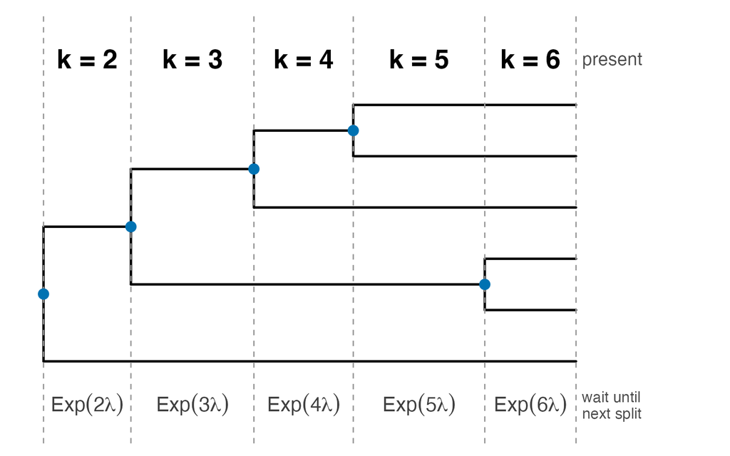

## Yule growth is exponential

Each lineage adds new lineages at rate $\lambda$, so on average

$$\frac{dN}{dt} = \lambda N
\quad\Longrightarrow\quad
E[N(t)] = N_0\, e^{\lambda t}.$$

- On a log axis that’s a straight line with slope $\lambda$.
- Single runs scatter a lot around the average, mostly early on, while only a few lineages exist.

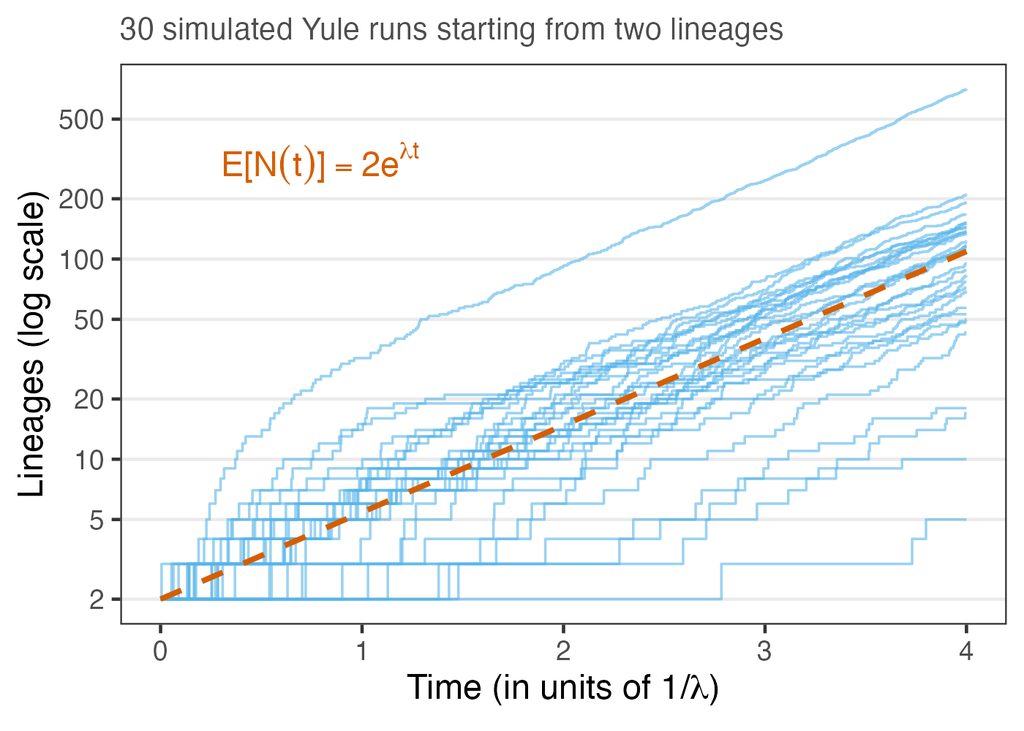

## Yule’s explanation of that heavy tail

- Start a genus from one species. After time $t$ its size is geometric:

$$P(N(t) = n) = e^{-\lambda t}\left(1 - e^{-\lambda t}\right)^{n-1}.$$

- Young genera are mostly small and old ones can be huge. New genera keep appearing, so most genera are young (Yule 1925).
- Mix genera of all ages and you get the hollow curve. The simulation looks a lot like the real data.

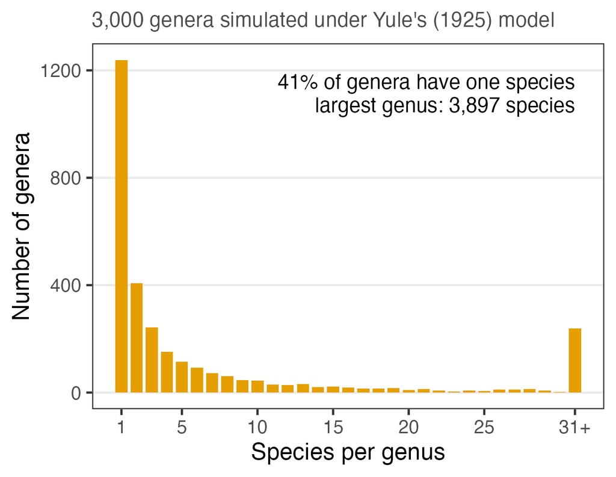

## Disentangling sister-group tests

- Sister-group comparisons control for time: both clades have the same stem age.
- A valuable approach to testing how traits or otherwise affect diversification rates.

## Replicated sister-group tests

- Compare many independent origins of a trait. Does the clade with the trait out-number its sister more often than chance?
- Latex and resin canals: canal-bearing clades were richer in 13 of 16 comparisons (Farrell, Dussourd, and Mitter 1991). A much larger re-test with newer phylogenies found little support (Foisy et al. 2019).
- Floral nectar spurs: spurred clades such as *Aquilegia* were richer than their spurless sisters (Hodges and Arnold 1995).
- These were the first tests of key innovations.

## Richness = time × rate

Under constant rates the expected number of lineages grows as $E[N(t)] = N_0\, e^{rt}$ (for pure birth, $r = \lambda$). Restructure to get an estimate or $r$ from a clade’s richness $n$ and age $t$ (Magallón and Sanderson 2001):

$$\hat r_{\text{stem}} = \frac{\ln n}{t}, \qquad
\hat r_{\text{crown}} = \frac{\ln n - \ln 2}{t}$$

**Worked example (species per lineage per Myr)**

| Clade | $n$ | $t$ (Myr) | $\hat r$ |
| --- | --- | --- | --- |
| Angiosperms (crown) | ~295,000 | ~140 | $(12.6 - 0.7)/140 \approx 0.085$ |
| *Amborella* (stem) | 1 | ~140 | $\ln 1 / 140 = 0$ |
| Andean *Lupinus* | 81 | 1.18–1.76 | $2.49$–$3.72$ |

*Lupinus* in the Andes is diversifying 30 to 45 times faster than the angiosperm average (Hughes and Eastwood 2006).

## Fast and slow plant lineages

**Fast** (species per lineage per Myr)

- Andean *Lupinus*: 2.5–3.7 (Hughes and Eastwood 2006)
- European *Dianthus*: 2.2–7.6 (Valente, Savolainen, and Vargas 2010)
- Ruschioid ice plants, 1,563 species: 0.77–1.75 (Klak, Reeves, and Hedderson 2004)
- Hawaiian silverswords: at least 0.56 (Baldwin and Sanderson 1998)

**Slow, or high turnover?**

- *Ginkgo biloba*: one living species, from a lineage with a long fossil record
- *Amborella*: one species on a ~140-Myr stem
- Cycads: an old group, but most living species arose in the last 10 Myr (Nagalingum et al. 2011)

A “slow” lineage might have low speciation, or high speciation matched by high extinction. Living species alone can’t tell these apart; fossils help.

## Exceptional clades: diversity envelopes

- Pick a background rate, such as the angiosperm average $\hat r = 0.085$.
- For each clade age, work out the richness you’d expect at that rate. The bands hold 95% of outcomes, for low and high turnover (Magallón and Sanderson 2001).
- Clades above the band are unusually rich, and clades below it are unusually poor.
- Can you name a clade that is more or less than the average?

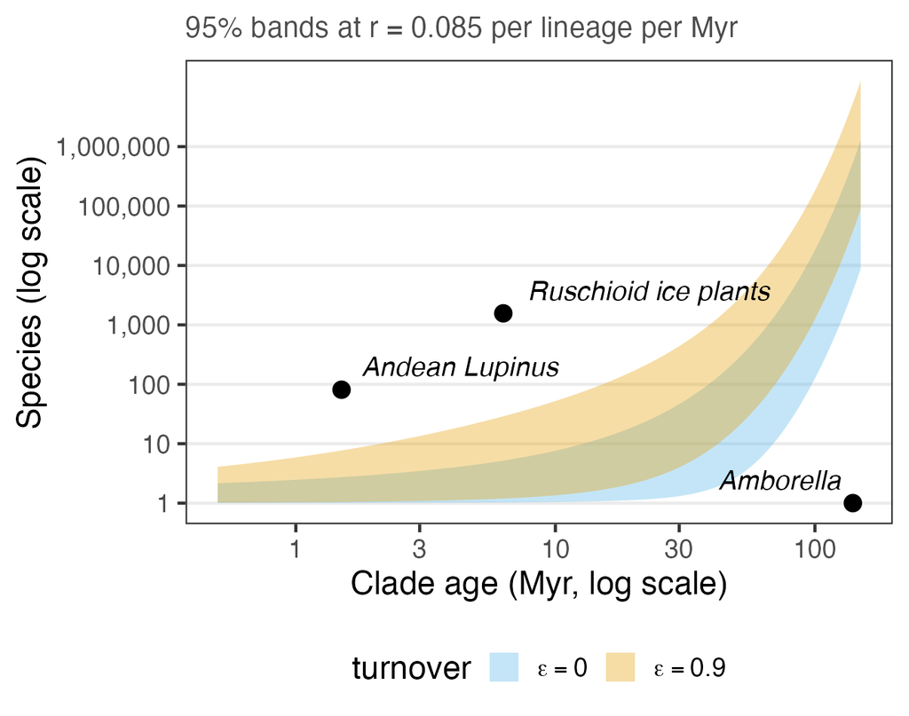

## Does clade age explain richness?

**Time for speciation**

- Older clades have had longer to build up species, and diversity keeps growing (McPeek and Brown 2007; Wiens 2011; Harmon and Harrison 2015).

**Ecological limits**

- Richness levels off as clades fill the available niches, so age and richness come apart (Rabosky 2009; Rabosky, Slater, and Alfaro 2012; Rabosky and Hurlbert 2015).

# More than population-level processes?

## The paradox of stasis

- Evolution measured over a few generations can be fast (Hendry and Kinnison 1999), but measured rates drop as the time interval gets longer (Gingerich 1983).
- In real data, divergence stays bounded for about a million years and only then builds up. Populations tracking an optimum that occasionally jumps fits that pattern (Uyeda et al. 2011; Estes and Arnold 2007).

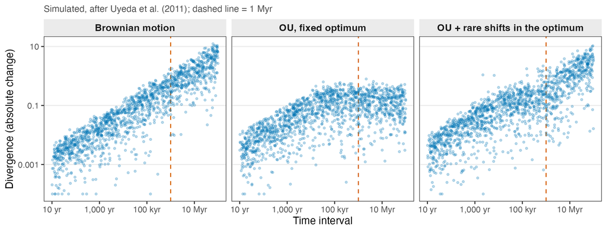

## Example: the million-year wait

Uyeda et al. (2011) put together more than 8,000 body-size measurements, from field studies to fossils to comparisons among living species.

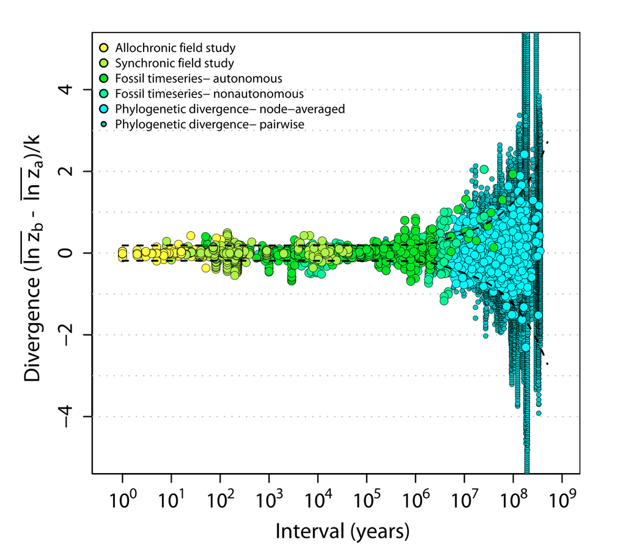

Fig. 1 from Uyeda et al. (2011)

## Example: why is self-incompatibility still around?

**Within populations, selfing should win**

- Selfing reduces genetic diversity but gives reproductive assurance.
- Self-incompatibility (SI) is lost again and again, and the loss is close to irreversible (Igić, Lande, and Kohn 2008).

**Across lineages, SI hangs on**

- In Solanaceae, SI lineages diversify faster than self-compatible (SC) lineages (Goldberg et al. 2010).

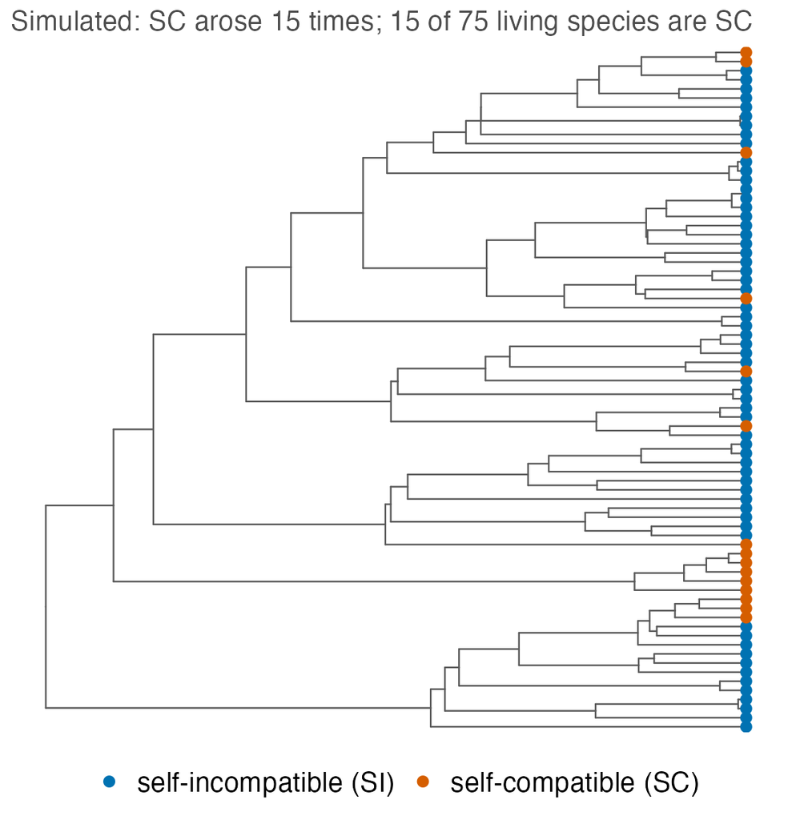

## Example: why is self-incompatibility still around?

The *Binary State-dependent Speciation and Extinction* (BiSSE) model. A preview of later activities.

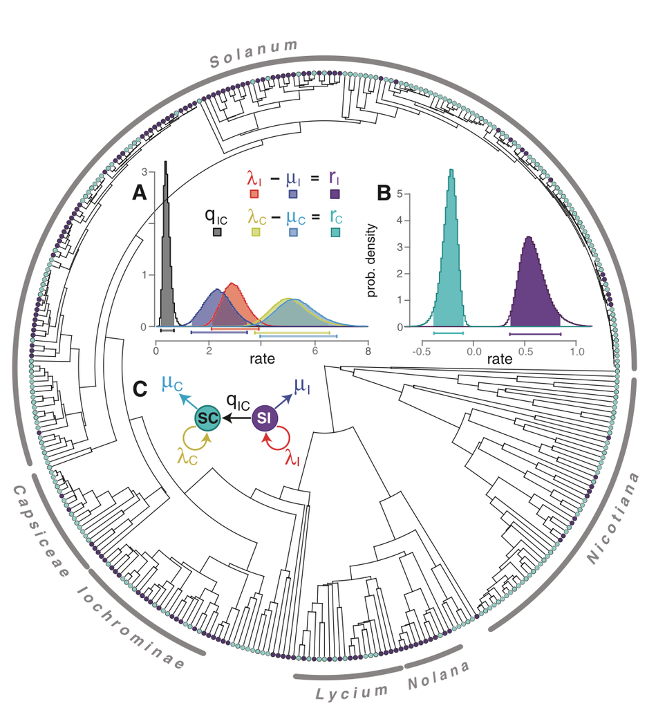

Fig. 1 from Goldberg et al. (2010)

## Example: why is self-incompatibility still around?

Selection among individuals favors losing SI, but it is maintained across some lineages regardless.

- Stebbins hypothesized that selfing is an evolutionary dead end (Stebbins 1957).
- Onagraceae show the same thing: SC lineages have higher extinction and lower net diversification (Freyman and Höhna 2019).
- One caution: BiSSE can be misleading when there are important unobserved intermediate states (Rabosky and Goldberg 2015).

## So, is macroevolution just microevolution with more time?

A whole-genome duplication is a mutation in one individual, and can be a speciation event in one generation, and may shift a clade’s diversification rate. Which level does polyploidy belong to?

Drastic shifts in phenotype can be driven by relatively few genetic changes, such as loss of flower pigment. Under what consditions would you expect such changes to lead to higher speciation rates?

# The framework

## Speciation and extinction on a tree

Lineages split (blue dots) and some die out (crosses). We only sample living species, so the tree we estimate is the reconstructed tree on the right. Extinct lineages leave no branches in it.

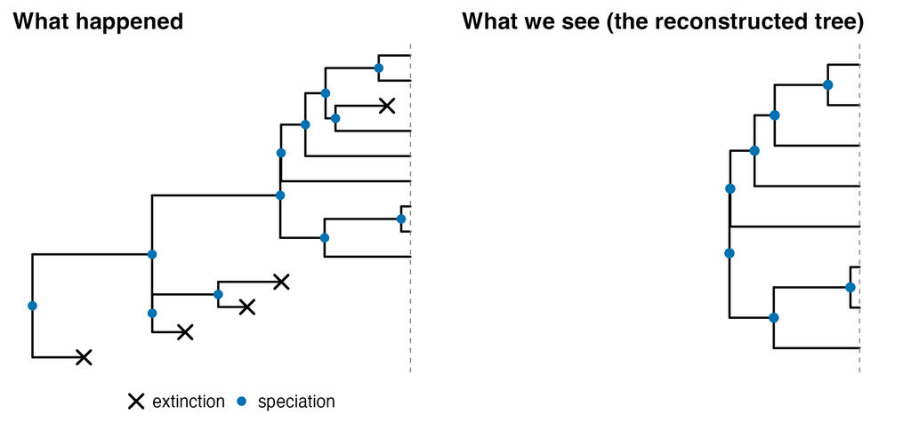

## Birth–death, previewed

Model a clade as lineages that speciate at rate $\lambda$ and go extinct at rate $\mu$:

$$E[N(t)] = N_0\, e^{(\lambda-\mu)t}, \qquad
r = \lambda - \mu, \qquad
\epsilon = \mu/\lambda .$$

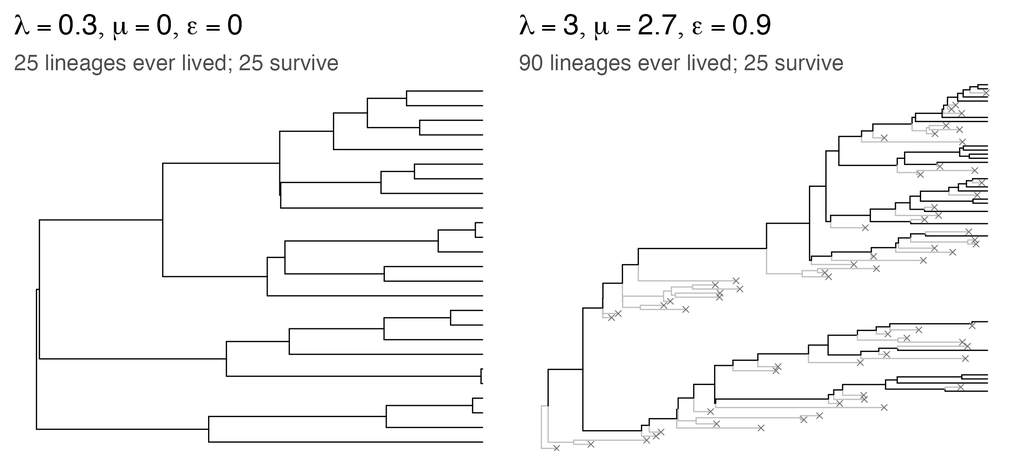

## Lineage-through-time plots

- Slide a line from the root to the present and count the lineages it crosses. Each split adds one.
- Plot that count on a log axis. Under a constant-rate Yule process you’d expect a roughly straight line with slope $\lambda$.
- An LTT is a quick look at the tempo of a tree before fitting any model.

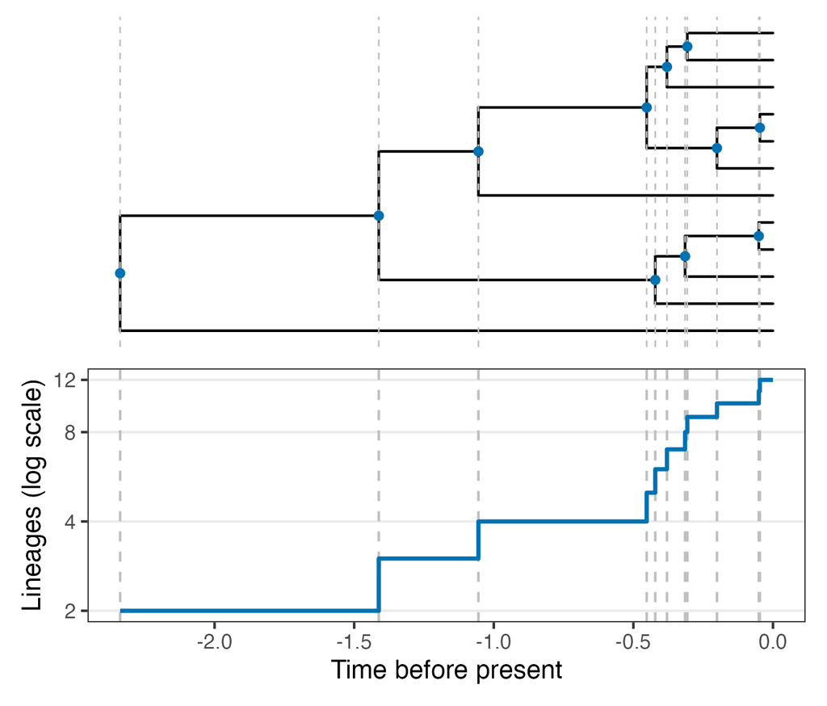

## Reading LTT shapes

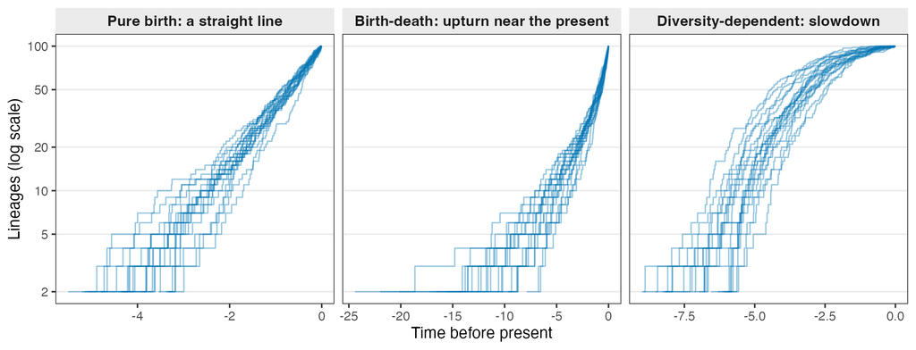

- With extinction, the curve bends up near the present.
- A slowdown can mean diversity-dependence.

## What birth–death can and can’t tell us

From living species alone, many different $\lambda(t)$ and $\mu(t)$ histories fit a timetree equally well (Louca and Pennell 2020). It’s the same kind of problem as rate and time in dating.

This gets into problems of **statistical identifiability**.

# Key takeaways

## Summary

- Macroevolution is about the birth and death of lineages.
- Plant diversity is uneven among clades, families and genera.
- The Yule process grows exponentially, with waits of $1/(k\lambda)$ between splits.
- Richness depends on time and rate. Sister groups and diversity envelopes help separate the two.
- LTT plots give an assessment of how lineage numbers have changed over time.

# References

Baldwin, Bruce G., and Michael J. Sanderson. 1998. “Age and Rate of Diversification of the Hawaiian Silversword Alliance (Compositae).” *Proceedings of the National Academy of Sciences* 95 (16): 9402–6. https://doi.org/10.1073/pnas.95.16.9402.

de Queiroz, Kevin. 2007. “Species Concepts and Species Delimitation.” *Systematic Biology* 56 (6): 879–86. https://doi.org/10.1080/10635150701701083.

Dobzhansky, Theodosius. 1937. *Genetics and the Origin of Species*. New York: Columbia University Press.

Estes, Suzanne, and Stevan J. Arnold. 2007. “Resolving the Paradox of Stasis: Models with Stabilizing Selection Explain Evolutionary Divergence on All Timescales.” *The American Naturalist* 169 (2): 227–44. https://doi.org/10.1086/510633.

Farrell, Brian D., David E. Dussourd, and Charles Mitter. 1991. “Escalation of Plant Defense: Do Latex and Resin Canals Spur Plant Diversification?” *The American Naturalist* 138 (4): 881–900. https://doi.org/10.1086/285258.

Foisy, Michael R., Loren P. Albert, Daniel W. W. Hughes, and Marjorie G. Weber. 2019. “Do Latex and Resin Canals Spur Plant Diversification? Re-examining a Classic Example of Escape and Radiate Coevolution.” *Journal of Ecology* 107 (4): 1606–19. https://doi.org/10.1111/1365-2745.13203.

Freyman, William A., and Sebastian Höhna. 2019. “Stochastic Character Mapping of State-Dependent Diversification Reveals the Tempo of Evolutionary Decline in Self-Compatible Onagraceae Lineages.” *Systematic Biology* 68 (3): 505–19. https://doi.org/10.1093/sysbio/syy078.

Frodin, David G. 2004. “History and Concepts of Big Plant Genera.” *TAXON* 53 (3): 753–76. https://doi.org/10.2307/4135449.

Gingerich, Philip D. 1983. “Rates of Evolution: Effects of Time and Temporal Scaling.” *Science* 222 (4620): 159–61. https://doi.org/10.1126/science.222.4620.159.

Goldberg, Emma E., Joshua R. Kohn, Russell Lande, Kelly A. Robertson, Stephen A. Smith, and Boris Igić. 2010. “Species Selection Maintains Self-Incompatibility.” *Science* 330 (6003): 493–95. https://doi.org/10.1126/science.1194513.

Goldschmidt, Richard. 1940. *The Material Basis of Evolution*. New Haven: Yale University Press.

Gould, Stephen Jay. 1980. “Is a New and General Theory of Evolution Emerging?” *Paleobiology* 6 (1): 119–30. https://doi.org/10.1017/s0094837300012549.

———. 2002. *The Structure of Evolutionary Theory*. Cambridge, MA: Belknap Press of Harvard University Press.

Harmon, Luke J., and Susan Harrison. 2015. “Species Diversity Is Dynamic and Unbounded at Local and Continental Scales.” *The American Naturalist* 185 (5): 584–93. https://doi.org/10.1086/680859.

Hendry, Andrew P., and Michael T. Kinnison. 1999. “Perspective: The Pace of Modern Life: Measuring Rates of Contemporary Microevolution.” *Evolution* 53 (6): 1637–53. https://doi.org/10.2307/2640428.

Hodges, Scott A., and Michael L. Arnold. 1995. “Spurring Plant Diversification: Are Floral Nectar Spurs a Key Innovation?” *Proceedings of the Royal Society B: Biological Sciences* 262 (1365): 343–48. https://doi.org/10.1098/rspb.1995.0215.

Hughes, Colin, and Ruth Eastwood. 2006. “Island Radiation on a Continental Scale: Exceptional Rates of Plant Diversification After Uplift of the Andes.” *Proceedings of the National Academy of Sciences* 103 (27): 10334–39. https://doi.org/10.1073/pnas.0601928103.

Igić, Boris, Russell Lande, and Joshua R. Kohn. 2008. “Loss of Self-Incompatibility and Its Evolutionary Consequences.” *International Journal of Plant Sciences* 169 (1): 93–104. https://doi.org/10.1086/523362.

Jablonski, David. 2008. “Species Selection: Theory and Data.” *Annual Review of Ecology, Evolution, and Systematics* 39 (1): 501–24. https://doi.org/10.1146/annurev.ecolsys.39.110707.173510.

Klak, C., G. Reeves, and T. Hedderson. 2004. “Unmatched Tempo of Evolution in Southern African Semi-Desert Ice Plants.” *Nature* 427 (6969): 63–65. https://doi.org/10.1038/nature02243.

Louca, Stilianos, and Matthew W. Pennell. 2020. “Extant Timetrees Are Consistent with a Myriad of Diversification Histories.” *Nature* 580 (7804): 502–5. https://doi.org/10.1038/s41586-020-2176-1.

Magallón, Susana, Sandra Gómez-Acevedo, Luna L. Sánchez-Reyes, and Tania Hernández-Hernández. 2015. “A Metacalibrated Time-Tree Documents the Early Rise of Flowering Plant Phylogenetic Diversity.” *New Phytologist* 207 (2): 437–53. https://doi.org/10.1111/nph.13264.

Magallón, Susana, and Michael J. Sanderson. 2001. “Absolute Diversification Rates in Angiosperm Clades.” *Evolution* 55 (9): 1762–80. https://doi.org/10.1554/0014-3820(2001)055[1762:adriac]2.0.co;2.

Mayrose, Itay, Shing H. Zhan, Carl J. Rothfels, Karen Magnuson-Ford, Michael S. Barker, Loren H. Rieseberg, and Sarah P. Otto. 2011. “Recently Formed Polyploid Plants Diversify at Lower Rates.” *Science* 333 (6047): 1257–57. https://doi.org/10.1126/science.1207205.

McPeek, Mark A., and Jonathan M. Brown. 2007. “Clade Age and Not Diversification Rate Explains Species Richness Among Animal Taxa.” *The American Naturalist* 169 (4): E97–106. https://doi.org/10.1086/512135.

Nagalingum, N. S., C. R. Marshall, T. B. Quental, H. S. Rai, D. P. Little, and S. Mathews. 2011. “Recent Synchronous Radiation of a Living Fossil.” *Science* 334 (6057): 796–99. https://doi.org/10.1126/science.1209926.

Philiptschenko, Jurij. 1927. *Variabilität Und Variation*. Berlin: Gebrüder Borntraeger.

Rabosky, Daniel L. 2009. “Ecological Limits and Diversification Rate: Alternative Paradigms to Explain the Variation in Species Richness Among Clades and Regions.” *Ecology Letters* 12 (8): 735–43. https://doi.org/10.1111/j.1461-0248.2009.01333.x.

Rabosky, Daniel L., and Emma E. Goldberg. 2015. “Model Inadequacy and Mistaken Inferences of Trait-Dependent Speciation.” *Systematic Biology* 64 (2): 340–55. https://doi.org/10.1093/sysbio/syu131.

Rabosky, Daniel L., and Allen H. Hurlbert. 2015. “Species Richness at Continental Scales Is Dominated by Ecological Limits.” *The American Naturalist* 185 (5): 572–83. https://doi.org/10.1086/680850.

Rabosky, Daniel L., Graham J. Slater, and Michael E. Alfaro. 2012. “Clade Age and Species Richness Are Decoupled Across the Eukaryotic Tree of Life.” *PLoS Biology* 10 (8): e1001381. https://doi.org/10.1371/journal.pbio.1001381.

Simpson, George Gaylord. 1944. *Tempo and Mode in Evolution*. New York: Columbia University Press.

Stebbins, G. Ledyard. 1957. “Self Fertilization and Population Variability in the Higher Plants.” *The American Naturalist* 91 (861): 337–54. https://doi.org/10.1086/281999.

Tank, David C., Jonathan M. Eastman, Matthew W. Pennell, Pamela S. Soltis, Douglas E. Soltis, Cody E. Hinchliff, Joseph W. Brown, Emily B. Sessa, and Luke J. Harmon. 2015. “Nested Radiations and the Pulse of Angiosperm Diversification: Increased Diversification Rates Often Follow Whole Genome Duplications.” *New Phytologist* 207 (2): 454–67. https://doi.org/10.1111/nph.13491.

Uyeda, Josef C., Thomas F. Hansen, Stevan J. Arnold, and Jason Pienaar. 2011. “The Million-Year Wait for Macroevolutionary Bursts.” *Proceedings of the National Academy of Sciences* 108 (38): 15908–13. https://doi.org/10.1073/pnas.1014503108.

Valente, Luis M., Vincent Savolainen, and Pablo Vargas. 2010. “Unparalleled Rates of Species Diversification in Europe.” *Proceedings of the Royal Society B: Biological Sciences* 277 (1687): 1489–96. https://doi.org/10.1098/rspb.2009.2163.

Vrba, Elisabeth S., and Stephen Jay Gould. 1986. “The Hierarchical Expansion of Sorting and Selection: Sorting and Selection Cannot Be Equated.” *Paleobiology* 12 (2): 217–28. https://doi.org/10.1017/s0094837300013671.

Wiens, John J. 2011. “The Causes of Species Richness Patterns Across Space, Time, and Clades and the Role of ‘Ecological Limits’.” *The Quarterly Review of Biology* 86 (2): 75–96. https://doi.org/10.1086/659883.

Willis, J. C., and G. Udny Yule. 1922. “Some Statistics of Evolution and Geographical Distribution in Plants and Animals, and Their Significance.” *Nature* 109 (2728): 177–79. https://doi.org/10.1038/109177a0.

Yule, George Udny. 1925. “A Mathematical Theory of Evolution, Based on the Conclusions of Dr. J. C. Willis, F.R.S.” *Philosophical Transactions of the Royal Society of London. Series B* 213: 21–87. https://doi.org/10.1098/rstb.1925.0002.